# Презентация Лабораторной работы №11

Операционные системы

Петрова А.А.

Российский университет дружбы народов, Москва, Россия

20 апреля 2024

## Цель работы

Цель данной лабораторной работы - познакомиться с операционной системой Linux. Получить практические навыки работы с редактором Emacs.

## Задание

1. Ознакомиться с теоретическим материалом.
2. Ознакомиться с редактором emacs.
3. Выполнить упражнения.
4. Ответить на контрольные вопросы

## Теоретическое введение

Emacs — один из наиболее мощных и широко распространённых редакторов, используемых в мире UNIX. По популярности он соперничает с редактором vi и его клонами. В зависимости от ситуации, Emacs может быть:

- текстовым редактором;
- программой для чтения почты и новостей Usenet;
- интегрированной средой разработки (IDE);
- операционной системой;

Всё это разнообразие достигается благодаря архитектуре Emacs, которая позволяет расширять возможности редактора при помощи языка Emacs Lisp. На языке C написаны лишь самые базовые и низкоуровневые части Emacs, включая полнофункциональный интерпретатор языка Lisp. Таким образом, Emacs имеет встроенный язык программирования, который может использоваться для настройки, расширения и изменения поведения редактора. В действительности, большая часть того редактора, с которым пользователи Emacs работают в наши дни, написана на языке Lisp.

## Теоретическое введение

Первая версия редактора Emacs была написана в 70-х годах 20-го столетия Richard Stallman (Ричардом Столманом) как набор макросов для редактора TECO . В дальнейшем, уже будучи основателем Фонда Свободного программного обеспечения Free Software Foundation и проекта GNU, Stallman разработал GNU Emacs в развитие оригинального Emacs и до сих пор сопровождает эту программу. Emacs является одним из старейших редакторов. Он использовался тысячами программистов на протяжении последних 20 с лишним лет, для него создано много дополнительных пакетов расширений. Эти дополнения позволяют делать с помощью Emacs такие вещи, которые Stallman , вероятно, даже не считал возможными в начале своей работы над редактором.

## Выполнение лабораторной работы

Сначала я установила Emacs.

Открываю Emacs через терминал (рис.1).

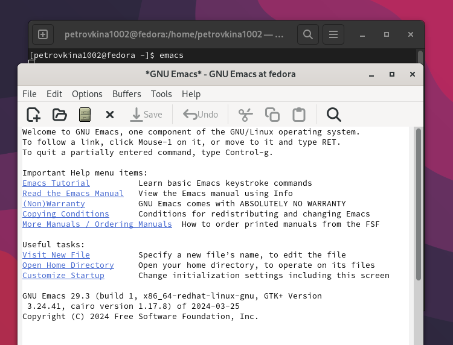

Открытие программы

## Выполнение лабораторной работы

Создаю файл lab07.sh с помощью комбинации Ctrl-x Ctrl-f (рис.2).

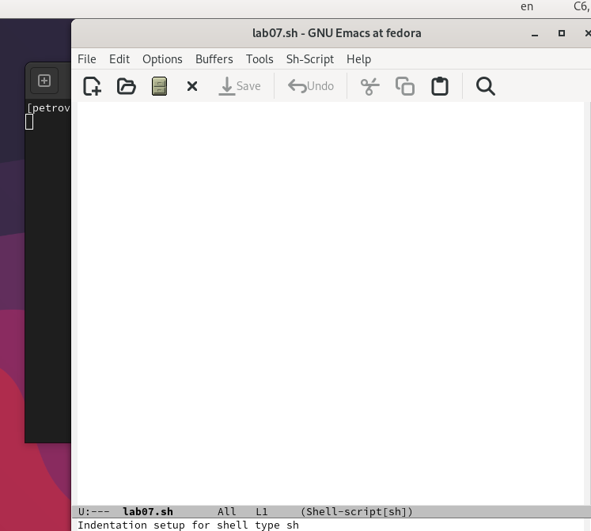

Создание файла

## Выполнение лабораторной работы

Прописываю в файле текст программы (рис.3).

[figure not shown]

Редактирование файла

## Выполнение лабораторной работы

Сохраняю файл с помощью комбинации C-x C-s (рис.4).

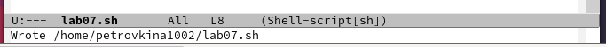

Сохранение изменений в файле

## Выполнение лабораторной работы

Вырезаю одной командой целую строку (С-k) (рис.5).

[figure not shown]

Вырезание строки

## Выполнение лабораторной работы

Вставляю эту строку в конец файла (C-y) (рис.6).

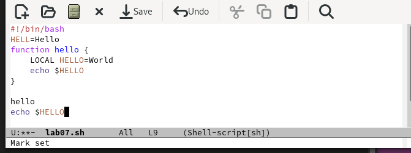

Вставка строки в конце файла

## Выполнение лабораторной работы

Выделяю область текста (C-space), копирую область в буфер обмена (M-w), вырезаю эту область с помощью C-w (рис.7).

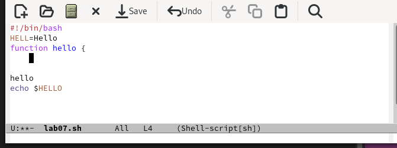

Вырезанная область

## Выполнение лабораторной работы

Вставляю область в конец файла (С-у)(рис.8).

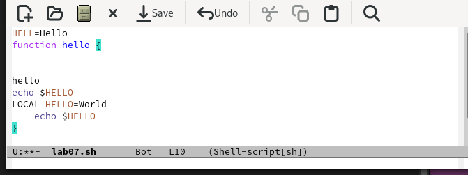

Вставка в конец файла

## Выполнение лабораторной работы

Отменяю последнее действие С-/ (рис.9).

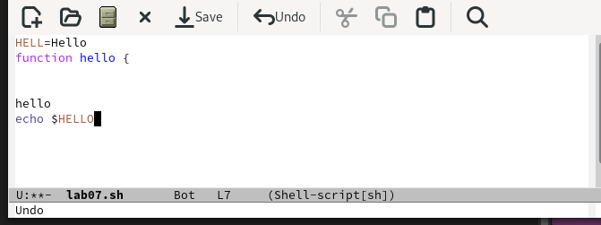

Отмена последнего действия

## Выполнение лабораторной работы

Перевожу курсор в начало строки С-а (рис.10).

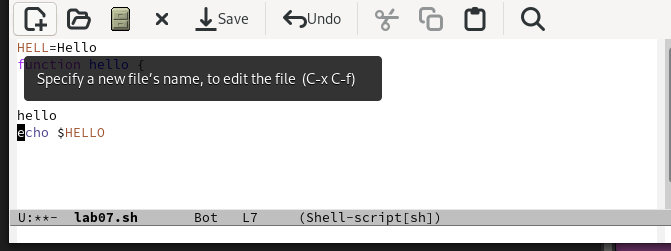

Курсор в начале строки

## Выполнение лабораторной работы

Перемещаю курсор в конец строки С-е (рис. 11).

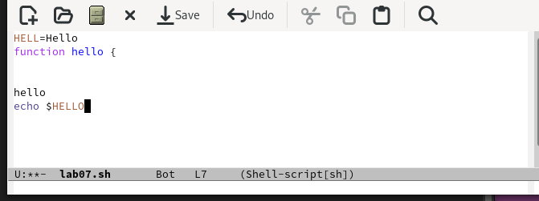

Курсор в конце строки

## Выполнение лабораторной работы

Перемещаю курсор в начало файла М-< (рис.12).

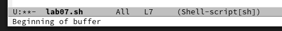

Начало буфер

## Выполнение лабораторной работы

Перемещаю курсор в конец файлаM->(рис. 13).

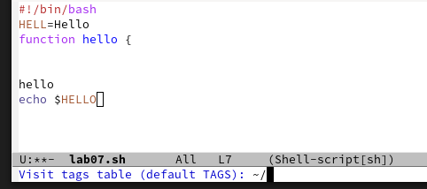

Конец буфера

## Выполнение лабораторной работы

Открываю список активных буферов в другом окне C-x C-b (рис.14).

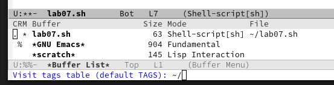

Список активных буферов

## Выполнение лабораторной работы

Переключаюсь на другой буфер C-x o (рис.15).

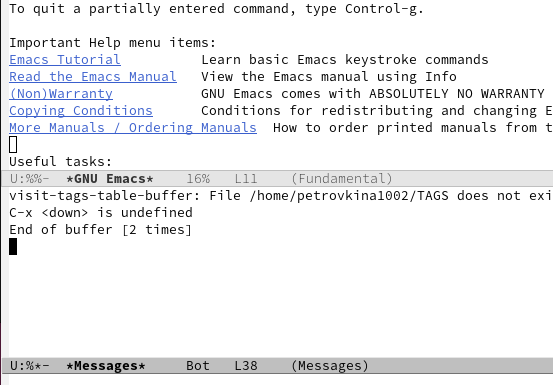

Другое окно буфера

## Выполнение лабораторной работы

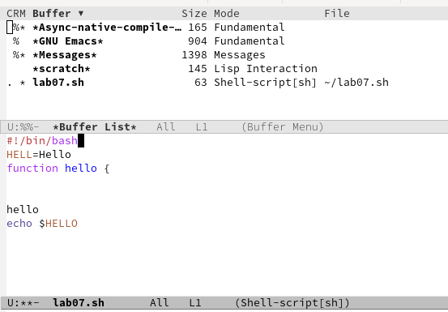

Закрытие буфера

## Выполнение лабораторной работы

Открываю другой буфер без вывода их списка на экран с помощью C-x b(рис.17).

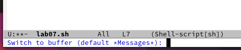

Открытие другого буфера

## Выполнение лабораторной работы

Делю фрейм на 4 части: сначала на два окна по вертикали (C-x 3), а затем каждое из этих окон на две части по горизонтали (C-x 2) (рис.18).

[figure not shown]

Четыре окна

## Выполнение лабораторной работы

В каждом из четырех созданных окон с помощью C-x b открыла разные буферы и (рис.19).

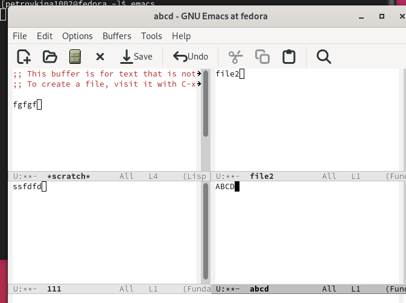

Открытие буферов в четырех окнах

## Выполнение лабораторной работы

Перехожу в режим поиска с помощью C-s, ищу слова в тексте, они подсвечиваются (рис.20).

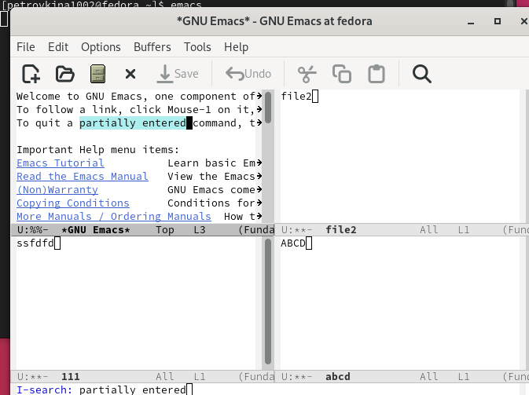

Режим поиска

## Выполнение лабораторной работы

С помощью той же комбинации C-s я могу перемещаться по результатам поиска (рис.21).

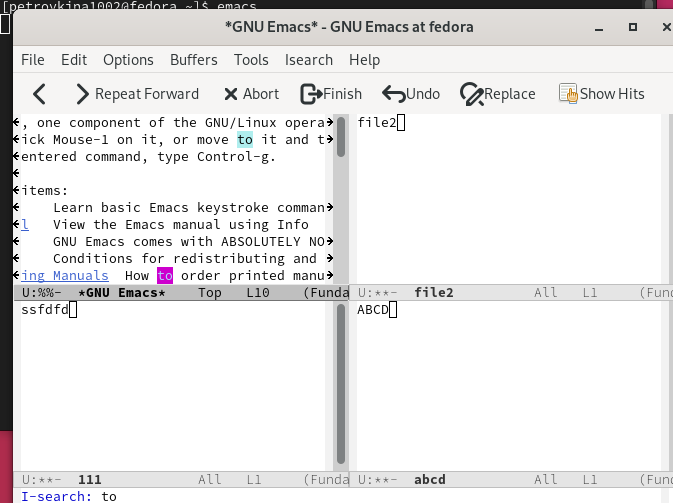

Перемещение по найденным выражениям

## Выполнение лабораторной работы

С помощью C-g выхожу из режима поиска, снимается выделение (рис.22).

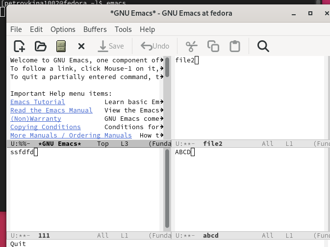

Выход из режима поиска

## Выполнение лабораторной работы

Перехожу в режим поиска и замены с помощью M-%, ввожу какое слово хочу заменить, затем ввожу на какое хочу заменить (рис.23).

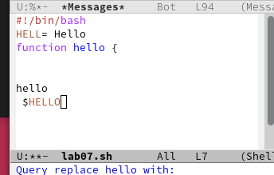

Замена слова

## Выполнение лабораторной работы

Видим, что слова были заменены успешно (рис.24).

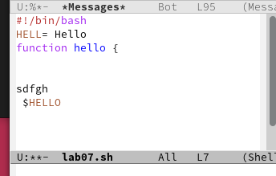

Слово заменено

## Выполнение лабораторной работы

С помощью M+s перехожу в другой режим поиска. Он отличается от предыдущего тем, что выводит результат в отдельном окне от окна буфера (рис.25).

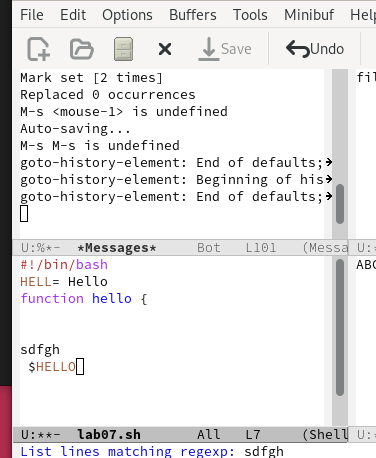

Режим поиска

## Выводы

В ходе данной работы я получила практические навыки работы с редактором Emacs.